# 05_triangle_perimeter

## 05_triangle_perimeter

#### Question

1. Consider the triangle with vertices at the following coordinates:
   - (4, 2)
   - (7, 13)
   - (1, 18)

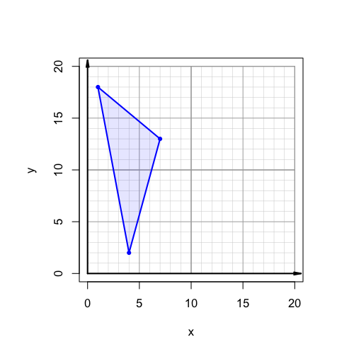

   Calculate the [perimeter](https://en.wikipedia.org/wiki/Perimeter). Please be accurate to within 0.01 units.

#### Question

2. Consider the triangle with vertices at the following coordinates:
   - (11, 5)
   - (14, 16)
   - (1, 10)

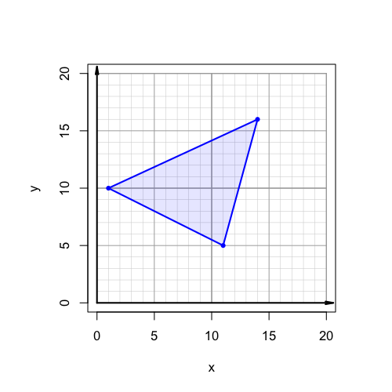

   Calculate the [perimeter](https://en.wikipedia.org/wiki/Perimeter). Please be accurate to within 0.01 units.

#### Question

3. Consider the triangle with vertices at the following coordinates:
   - (14, 9)
   - (10, 15)
   - (7, 5)

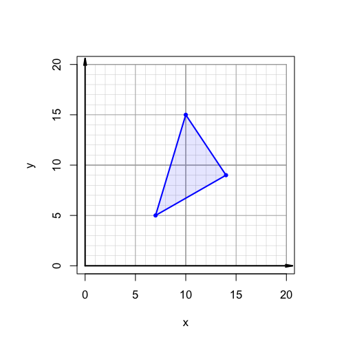

   Calculate the [perimeter](https://en.wikipedia.org/wiki/Perimeter). Please be accurate to within 0.01 units.

#### Question

4. Consider the triangle with vertices at the following coordinates:
   - (13, 9)
   - (8, 7)
   - (16, 14)

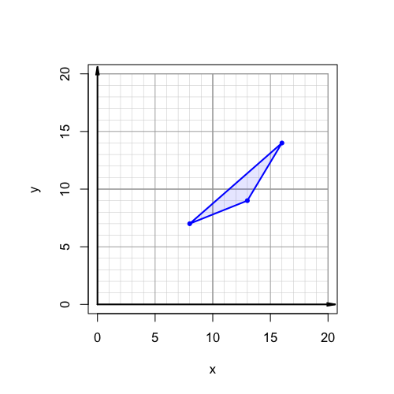

   Calculate the [perimeter](https://en.wikipedia.org/wiki/Perimeter). Please be accurate to within 0.01 units.

#### Question

5. Consider the triangle with vertices at the following coordinates:
   - (7, 1)
   - (2, 11)
   - (10, 15)

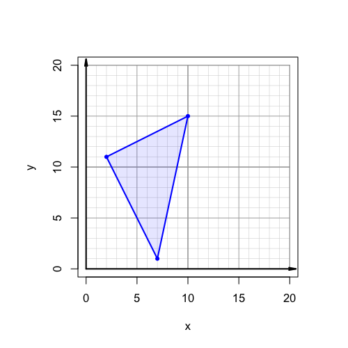

   Calculate the [perimeter](https://en.wikipedia.org/wiki/Perimeter). Please be accurate to within 0.01 units.

#### Question

6. Consider the triangle with vertices at the following coordinates:
   - (14, 5)
   - (6, 13)
   - (9, 19)

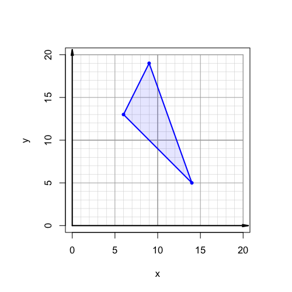

   Calculate the [perimeter](https://en.wikipedia.org/wiki/Perimeter). Please be accurate to within 0.01 units.

#### Question

7. Consider the triangle with vertices at the following coordinates:
   - (19, 9)
   - (12, 18)
   - (17, 2)

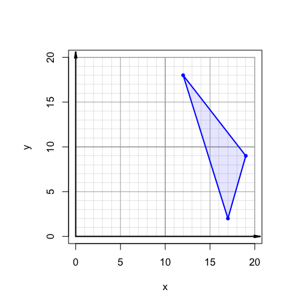

   Calculate the [perimeter](https://en.wikipedia.org/wiki/Perimeter). Please be accurate to within 0.01 units.

#### Question

8. Consider the triangle with vertices at the following coordinates:
   - (7, 10)
   - (9, 2)
   - (13, 15)

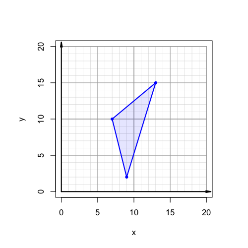

   Calculate the [perimeter](https://en.wikipedia.org/wiki/Perimeter). Please be accurate to within 0.01 units.